# Resumen cobertura bajo censura no aleatoria

## Introducción

En este documento describimos los resultados de un ajuste propuesta para la estimación de porcentaje de votos para candidatos bajo muestras censuradas por el tiempo.

Como discutimos en [presentaciones anteriores](https://sim-llegadas-3e5e7b.netlify.app/), la muestras censuradas por el tiempo típicamente no pueden considerarse como submuestras aleatorias de la muestra diseñada y presentan sesgos potenciales en la estimaciones que resultan en intervalos que pueden estar lejos de cumplir la cobertura nominal de 95%.

## Primeros resultados de cobertura

Los datos de cobertura con y sin ajuste de sesgo (usando 100 muestras) se muestran a continuación:

Número de muestras: 100

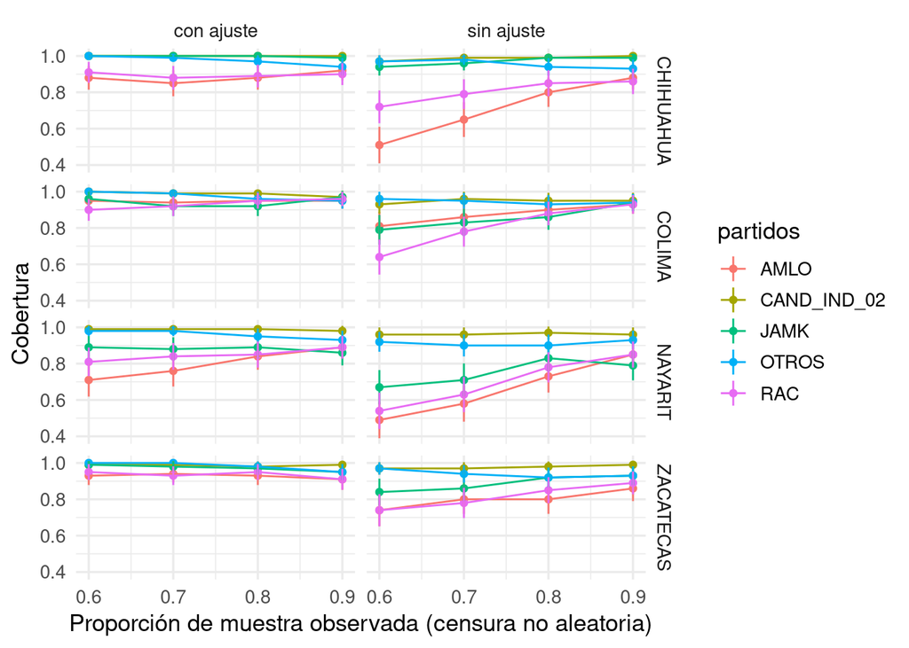

## Precisión

El incremento en tamaño de los intervalos producidos al introducir la corrección se muestra en la siguiente gráfica:

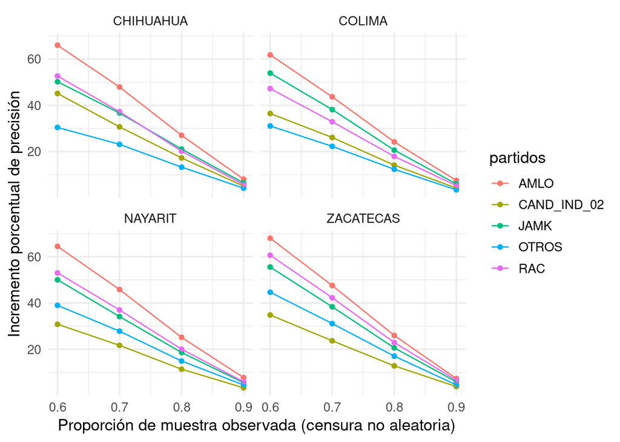

Lo que representa una mejoría considerable a lo largo de las estimaciones de todos los estados, pues las coberturas resumidas sin ajuste son:

| prop_obs | estado | precision_corregida | cobertura_corregida | precision | cobertura |
| --- | --- | --- | --- | --- | --- |
| 0.6 | CHIHUAHUA | 2.1 | 0.93 | 1.3 | 0.72 |
| 0.6 | COLIMA | 1.8 | 0.94 | 1.1 | 0.75 |
| 0.6 | NAYARIT | 1.7 | 0.80 | 1.0 | 0.57 |
| 0.6 | ZACATECAS | 1.9 | 0.96 | 1.1 | 0.77 |
| 0.9 | CHIHUAHUA | 1.1 | 0.94 | 1.0 | 0.91 |
| 0.9 | COLIMA | 0.9 | 0.96 | 0.8 | 0.93 |
| 0.9 | NAYARIT | 0.8 | 0.88 | 0.8 | 0.83 |
| 0.9 | ZACATECAS | 1.0 | 0.92 | 0.9 | 0.89 |

## Sesgo absoluto 2018

En [este documento](https://sim-llegadas-3e5e7b.netlify.app/) describimos el tamaño y patrón de sesgo producido por muestras censuradas en la elección presidencial de 2018, considerando sólo los estados con elección de gobernador en 2021.

En este documento se muestra (con un análisis exploratorio basado en simulaciones de tiempos de llegada y censura de acuerdo a esos tiempos) que el sesgo cuando hemos observado una proporción $p_{obs}$ de la muestra completa, cuando buscamos estimar una proporción $\theta$, es proporcional a
$$\theta(1-\theta)(1-p_{obs})$$
Aunque la constante de proporcionalidad varía de estado a estado, encontramos que en los peores casos la constante es de alrededor de $\alpha = 1/5$

## Ajuste por sesgo

En nuestro modelo bayesiano para la estimación del porcentaje de votos de cada candidato, modelamos los votos para un candidato en la casilla $i$ como
$$y_{i} \sim \textrm{NegBin} \left( \mu_i, \phi_i \right)$$

donde la media $\mu_i = n_i \theta_i$, $n_i$ es el tamaño de la lista nominal,y

$$\theta_i = h^{-1}(\beta_0 + \beta_{st(i)} + x_i^t\beta),$$
donde $h$ es la función liga logit, $x_i$ son covariables asociadas a la casila $i$, y $\beta_st$ depende del estrato donde está la casilla.

Una vez que simulamos de la posterior bajo este modelo, procedemos a simular el número de votos para **todas** las casillas del estado.

Cuando la muestra está censurada por tiempo, sabemos que existe sesgo. Utilizaremos la cuantificación de 2018 mostrada arriba para, en el paso de **simulación**, utilizar

$$\theta'_i = h^{-1}(\beta_0 + \beta_{st} + x_i^t\beta + w)$$
donde $w\sim N(0, s)$ se simula una vez para cada candidatos en cada simulación.

El valor $s$ se fija de acuerdo al sesgo que hemos observado en elecciones pasadas en estas proporciones $\theta_i$ cuando existen muestras incompletas, considerando que (aproximando a primer orden):
$$\theta'_i - \theta_i \approx \theta_i(1-\theta_i) w.$$
Fijando entonces $\theta_i$ obtenemos que 2 desviaciones estándar de esta cantidad son aproximadamente

$$2 \theta_i(1-\theta_i) s$$

De forma que igualando con la cantidad de arriba, obtenemos
$$s = \frac{1 - p_{obs}}{10}.$$
Dada la naturaleza aproximada de este análisis, podemos decidir la constante de proporcionalidad con datos de de elecciones anteriores, en lugar de usar los argumentos que acabamos de mostrar.

## Ejemplos: intervalos con y sin corrección con simulación de llegadas

En estos dos ejemplos vemos cómo podrían verse los intervalos con y sin corrección conforme observamos muestras censuradas según los patrones de 2018:

```
## [1] 318   6
```

```
## Model executable is up to date!
```

Sin corrección:

```r
prop_observadas <- c(0.025, 0.05, 0.25, 0.5, 0.6, 0.7, 0.8, 0.95, 0.99)
```

[output not shown]

[output cut: 71 more lines]

[output not shown]

[output not shown]

[output cut: 62 more lines]

[output not shown]

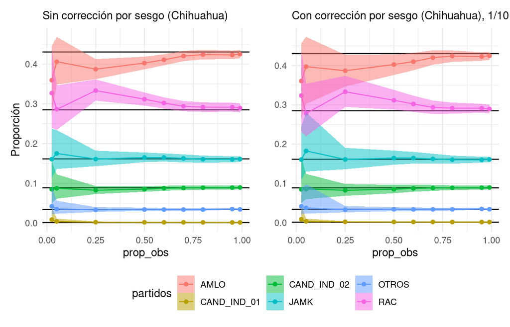

## Apéndice

Con un ajuste más grande de $s=(1-p_{obs})/7$, por ejemplo, obtenemos

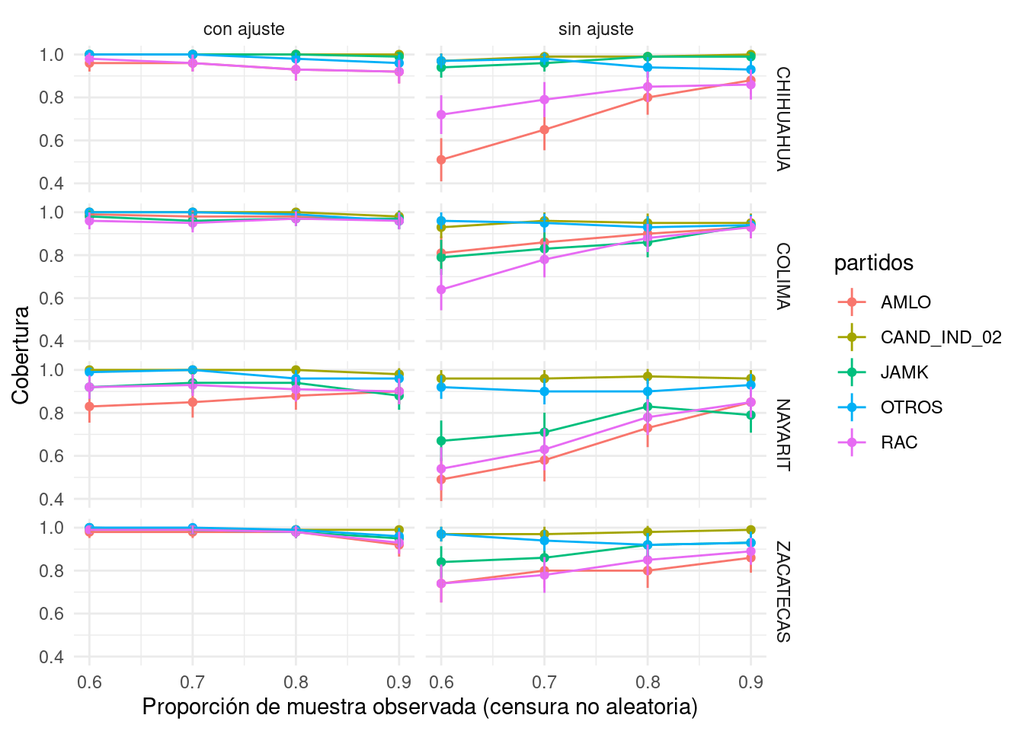

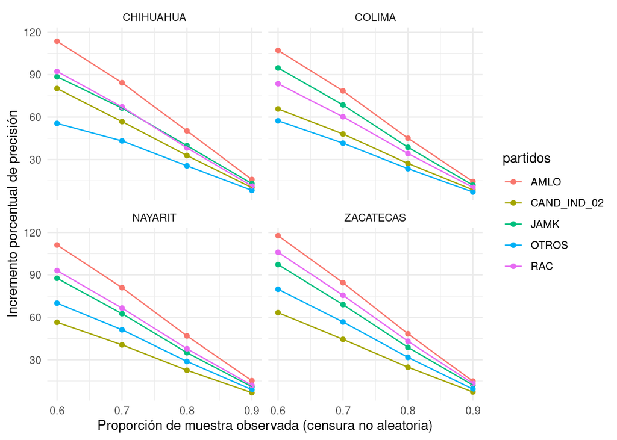

Lo que representa una mejoría considerable a lo largo de las estimaciones de todos los estados, pues las coberturas resumidas sin ajuste son:

| prop_obs | estado | precision_corregida | cobertura_corregida | precision | cobertura |
| --- | --- | --- | --- | --- | --- |
| 0.6 | CHIHUAHUA | 2.7 | 0.98 | 1.3 | 0.72 |
| 0.6 | COLIMA | 2.3 | 0.98 | 1.1 | 0.75 |
| 0.6 | NAYARIT | 2.2 | 0.89 | 1.0 | 0.57 |
| 0.6 | ZACATECAS | 2.4 | 0.99 | 1.1 | 0.77 |
| 0.9 | CHIHUAHUA | 1.2 | 0.94 | 1.0 | 0.91 |
| 0.9 | COLIMA | 1.0 | 0.96 | 0.8 | 0.93 |
| 0.9 | NAYARIT | 0.9 | 0.89 | 0.8 | 0.83 |
| 0.9 | ZACATECAS | 1.0 | 0.93 | 0.9 | 0.89 |